# Online Advertising Patterns

A visual data story about the ads I observed across online platforms

Nero Zhang

## What I Collected

For this project, I continued the data context from Project 2 by observing online advertisements that appeared while I used platforms such as YouTube, Instagram, TikTok, Facebook, and X. The data was collected through my Google Form, and the updated dataset contains 40 responses.

Each response records the platform where an ad was seen, the type of ad, the duration of the ad, whether it seemed attractive enough to click, and the time of day when it was observed. Because the original form allowed some multi-select answers, the visualisations interpret platform, ad type, and time-of-day results as **mentions** rather than always treating each selected category as a separate single ad.

## Where Ads Appeared

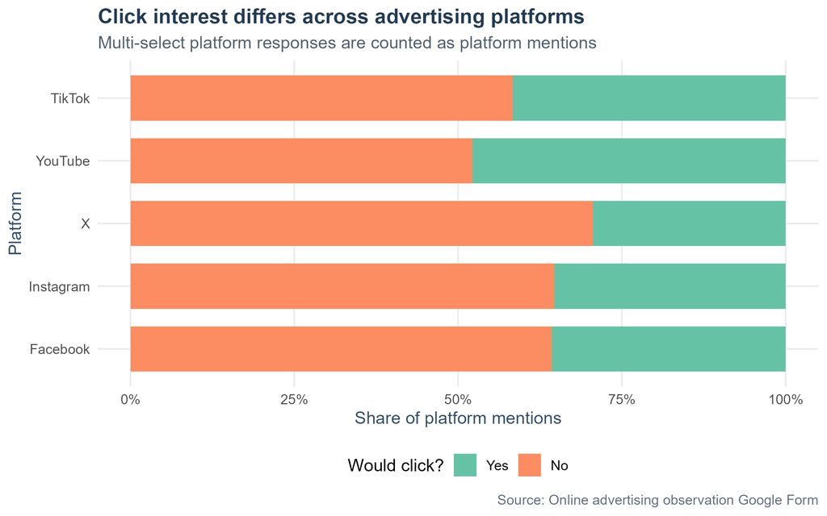

A horizontal stacked bar chart showing the share of Yes and No click responses for each online advertising platform. Platform responses are counted as mentions because the form allowed multiple platforms in one response.

The first part of the story compares platforms by click interest. This helps show not only where ads appeared often, but also whether ads from those platforms seemed more or less attractive to click. Counting platform mentions is useful here because several responses included more than one platform.

## What Ads Promoted

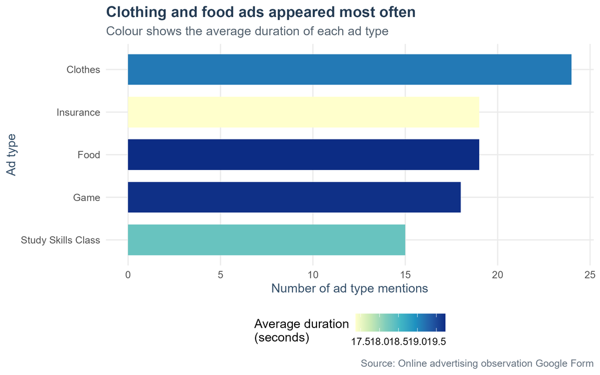

A horizontal bar chart showing the number of mentions for each ad type, with colour representing average ad duration in seconds. Clothes and food are among the most frequently mentioned ad categories.

The ad categories show what kinds of products or services appeared in my online environment. The colour scale adds another layer to the story by showing average ad duration. This makes the visualisation more informative than a simple frequency chart because it connects ad type with how long the ads tended to last.

## When Ads Felt Longer

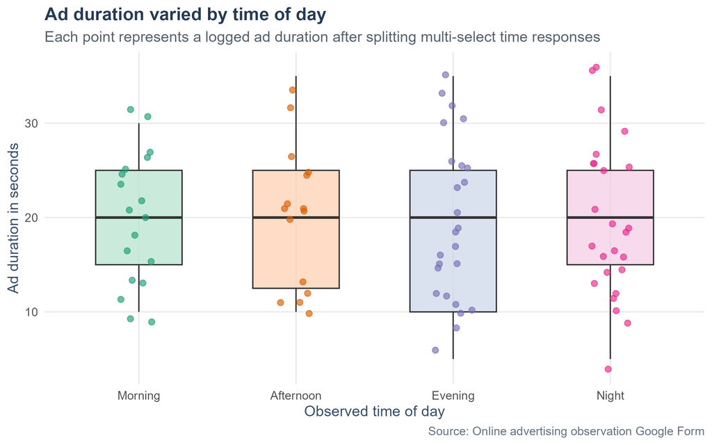

A boxplot with jittered points showing ad duration in seconds by observed time of day. The plot compares Morning, Afternoon, Evening, and Night after splitting multi-select time responses.

The time-of-day plot focuses on duration. It shows whether ads observed at different times tended to be shorter or longer. Since the form allowed multiple time periods in some responses, the code separates those selections before plotting them.

## How Collection Changed Over Time

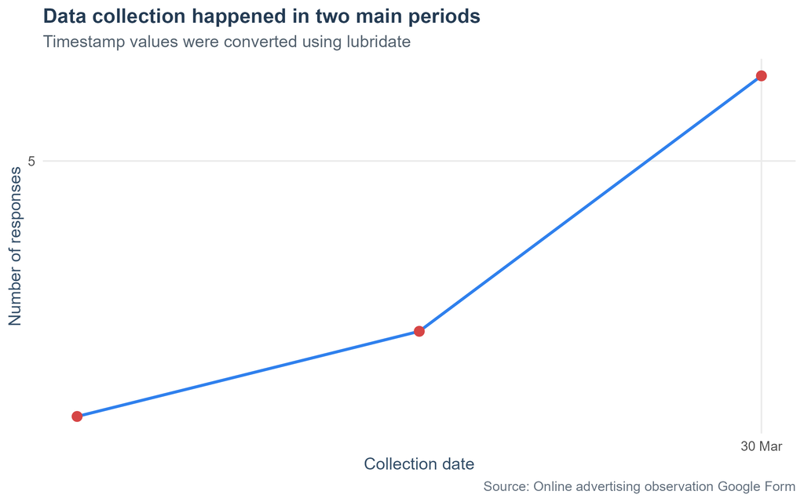

## Main Message

Overall, the visual story shows that online advertising is not evenly distributed across my platforms or ad categories. Some platforms and ad types appeared more often, while click interest and ad duration varied across the observations. The strongest story is that my everyday online advertising experience is shaped by both **where** I see ads and **what kind** of ads appear.

The main limitation is that the original Google Form allowed multi-select answers, so several plots are best interpreted as counts of category mentions. If I redesigned the form, I would make each response record one advertisement only, with single-choice questions for platform, ad type, and time of day.